# Advanced Empirical Finance: Topics and Data Science

Welcome, setup and financial data

Stefan Voigt

University of Copenhagen and Danish Finance Institute (DFI)

Spring 2027

# Welcome!

## Who is in the room?

A short anonymous survey in the first lecture:

- Who are you: master’s, exchange, or PhD student?
- How good are you at R, Python, and AI tools for coding?
- Which tools have you used?
- What do you mainly want to take away from this course?

## What AEF is about

**This course is about doing empirical finance: working with real data, from start to finish.**

**Theory**

What should hold

**Econometrics**

How to test it

**Data & code**

What we actually find

- AEF lives where the three meet: most results depend on choices made between the raw data and the final table
- Empirical finance is finance measured against reality, and financial markets provide vast data to inform financial decisions

**(How) can state-of-the-art methods improve financial decision making?**

## Why I teach this course

**Decisions with large data**

Portfolio choice for thousands of assets under transaction costs and estimation error (Hautsch & Voigt, 2019)

**Reproducibility**

How the choices researchers make change their results: non-standard errors (Gruber, Kastner, Voigt & Weiss, 2026; Voigt & Scheuch, 2026)

**Tidy Finance**

The open-source book with R and Python side by side that this course builds on: tidy-finance.org

## One thread through the course

One object all semester: the **mean-variance efficient portfolio**, which is also the **stochastic discount factor** $m$ that prices every asset, $1 = E[mR]$

**From portfolio choice to pricing**

Lectures 2–9

The efficient portfolio and its estimation error; shrinkage and transaction costs; the SDF and the CAPM; factors, sorts and reproducibility

**Machine learning and the SDF**

Lectures 10–16

Overfitting and out-of-sample evaluation; shrinking the SDF; latent factors; trees, forests and neural networks on the factor zoo

**Volatility, risk and uncertainty**

Lectures 17–21

Volatility and covariances from high-frequency data; covariance forecasts for portfolio choice; the conference session

## Your roadmap

**Kick-off**

Trading game dry run until 12 Feb

**Trading starts**

**Assignment 1**

Portfolio choice

**Assignment 2**

Machine learning, out of sample

**Assignment 3**

**Trading game closes**

**Conference session**

Easter break 22–26 March. The [lecture plan](https://aef-course.ku.dk/slides-index.html) has every date.

# How the course works

## Every week

- **Lectures:** Mondays 8–10 in even weeks (CSS 1-1-18) and Thursdays 13–15 (CSS 18-01-11): methods, theory and recent papers
- **Exercises**, one page per week, in two parts:
  - *Reproduce* a chapter of [Tidy Finance](https://www.tidy-finance.org) in R or Python; the solutions are in the book
  - *An open question* without a fixed solution: you submit a figure or a number, and the next lecture discusses the results of the whole class
- **Exercise classes:** open office hours, Mondays 8–10 in odd weeks (CSS 2-2-36). Bring your questions; nothing is presented

The learning curve is steep: ask early, on Absalon or in the exercise classes

## How you are assessed

Continuous assessment: what you hand in and present during the semester counts

- **Three mandatory assignments**, in teams of up to three
- **Peer feedback** on the assignments of other teams, individually
- **The conference session:** presentations and discussions

## Mandatory assignments

|  | Topic | Weeks |
| --- | --- | --- |
| 1 | Portfolio choice | 11–18 March |
| 2 | Machine learning in asset pricing, out of sample | 19–26 April |
| 3 | **TBD** | 3–10 May |

- One week each; the assignments and the data come through Absalon
- Hand in one `.qmd` file and the PDF rendered from it: at most 7 pages, 12 pt, in English, from the [templates](https://github.com/advanced-empirical-finance/course-repository/tree/main/mandatory-assignments)
- Every assignment builds on your team’s trading game decisions in one part
- The bar is high: the [assignment quality criteria](https://aef-course.ku.dk/additional-material/assignment-quality-criteria.html) say what a good submission looks like

## Peer feedback

- Peer feedback opens two days after the deadline and stays open for seven days
- Each of you gives feedback on **two** submissions of other teams
- Start by reproducing their report: does it render from their files, and do the numbers match?
- This is one of the most useful steps of the course: you see how others solved the same problem

## The trading game

[interactive chart not shown]

The 60-second introduction on the homepage: [aef-course.ku.dk/trading-game](https://aef-course.ku.dk/trading-game/)

## The trading game: what matters

- Your team runs a paper portfolio of US stocks, from $1,000,000, from 16 February to 14 May; the dry run is open until 12 February
- You send a weight vector with a rationale whenever you like; the game trades it at the next open
- The game is there to make you decide and to discuss decisions: every assignment builds on your team’s decisions
- **Conference session:** the teams with the best out-of-sample performance present their approach, and other students discuss it in front of faculty and quantitative traders; a jury picks the best team
- Start here: [the rules](https://aef-course.ku.dk/trading-game/) and [Getting started](https://aef-course.ku.dk/trading-game/getting-started.html)

## AI in this course

- You may, and you are expected to, use AI assistants for code, text and review
- In exchange, the bar is high: you answer for every line you hand in
- The course repository contains `AGENTS.md`: your assistant reads the course rules from there
- Never paste licensed data (CRSP) or your trading game token into a chat
- How to work with an assistant: [AI assistants](https://aef-course.ku.dk/additional-material/positron-ai-assistant.html)

## Team and contact

- Stefan Voigt (stefan.voigt@econ.ku.dk, www.voigtstefan.me)
- Teaching assistant: Nikolai Zakarias Zwisler (xjb522@econ.ku.dk)
- Questions about content go to the Absalon discussion board, so everyone benefits from the answer
- **TBD:** office hours, and whether lectures are recorded
- The rest of the team: your peers. Connect and help each other

# Your setup

## The toolbox

| Tool | What it does |
| --- | --- |
| **R or Python** | The language you write your analysis in |
| **Positron** | The editor: code, console, data viewer, Git and AI assistant in one place |
| **Quarto** | Weaves text and code into one report: your hand-ins are Quarto files rendered to PDF |
| **uv and uvr** | Install Python, R and exactly the course’s package versions |
| **Git and GitHub** | Version control and your team’s repository |

Set it up before the next lecture: [technical prerequisites](https://aef-course.ku.dk/exercises/technical-prerequisites.html)

## One environment for everyone

- The course repository records every package version: `uv.lock` for Python, `uvr.lock` for R
- Two commands install exactly these versions on your computer:

```bash
uvr sync
uv sync
```

- Why it matters: your peers run your code for peer feedback; with the same versions, it runs on their computer too
- Need another package? `uvr add <package>` or `uv add <package>`, then commit the lock files

## Your team repository

- Each team gets a private copy of the course repository on GitHub, created for you: course material, assignments and trading game code in one place
- Send your team’s GitHub usernames through the form on Absalon
- Before every hand-in, a teammate renders your report from a fresh copy: the pull request is the natural place for this check
- [Collaboration with Git and GitHub](https://aef-course.ku.dk/additional-material/github-collaboration.html) has every step

## R or Python?

- Both are open source, have large communities and are standard in finance
- Pick one; every exercise and every solution exists in both
- **Tidy coding** matters more than the language: clean code in either is readable for everyone
- You give feedback on R and Python submissions: with tidy code, you understand your peers’ code even in the other language

[figure not shown]

# Financial data

## Where the data come from

- **CRSP** (Center for Research in Security Prices): every US common stock since 1926, from WRDS. Licensed: you get it through Absalon
- **Public data**, downloaded with `tidyfinance`: the Fama-French factors and industry portfolios, the macroeconomic predictors of Welch and Goyal (2008), the consumer price index
- Everything lives as parquet files in the `data` folder of the course repository, as in the Tidy Finance book

| File | Content |
| --- | --- |
| `crsp_monthly.parquet` | CRSP monthly returns, market capitalization, exchange, industry (from Absalon) |
| `factors_ff3_monthly.parquet` | Fama-French three factors and the risk-free rate |
| `industries_ff_monthly.parquet` | Ten industry portfolios |
| `macro_predictors.parquet` | Welch and Goyal (2008) predictors |
| `cpi_monthly.parquet` | Consumer price index |

## Reading the data

- R
- Python

```r
crsp_monthly <- read_parquet("../data/crsp_monthly.parquet")
cpi_monthly <- read_parquet("../data/cpi_monthly.parquet")
```

```python
crsp_monthly = pl.read_parquet("../data/crsp_monthly.parquet")
cpi_monthly = pl.read_parquet("../data/cpi_monthly.parquet")
```

- The CRSP file is licensed: never commit it, never upload it, never paste it into an AI tool. Git ignores it in the course repository
- Read files with relative paths, so your code runs on your teammates’ computers too

## The CRSP universe: number of stocks

- R
- Python

```r
crsp_monthly |>
  count(exchange, date) |>
  ggplot(aes(x = date, y = n, color = exchange, linetype = exchange)) +
  geom_line() +
  labs(
    x = NULL, y = "Number of stocks", color = NULL, linetype = NULL,
    title = "Number of stocks in CRSP by listing exchange, monthly"
  ) +
  scale_y_continuous(labels = comma) +
  theme_bw() +
  theme(legend.position = "bottom")
```

```python
(
    ggplot(
        crsp_monthly.group_by("exchange", "date").len(),
        aes(x="date", y="len", color="exchange", linetype="exchange"),
    )
    + geom_line()
    + labs(
        x="", y="Number of stocks", color="", linetype="",
        title="Number of stocks in CRSP by listing exchange, monthly",
    )
    + scale_y_continuous(labels=comma_format())
    + theme_bw()
    + theme(legend_position="bottom")
)
```

Your first exercise: reproduce this figure from your own `data` folder

## The CRSP universe: number of stocks

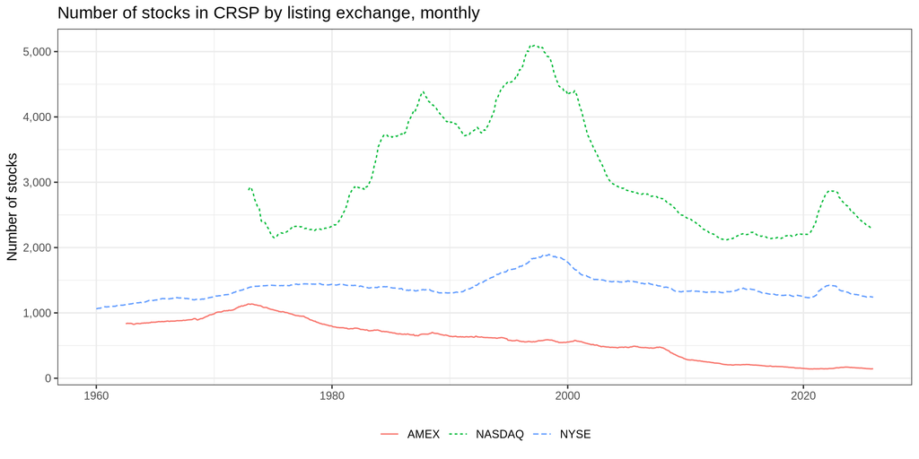

## The CRSP universe: market capitalization

- R
- Python

```r
# mktcap is in million USD; cpi is 1 in December 2025
crsp_monthly |>
  left_join(cpi_monthly |> select(date, cpi), join_by(date)) |>
  summarize(mktcap = sum(mktcap, na.rm = TRUE) / first(cpi), .by = c(date, exchange)) |>
  ggplot(aes(x = date, y = mktcap / 1e6, color = exchange, linetype = exchange)) +
  geom_line() +
  labs(
    x = NULL, y = "Trillion USD (December 2025 prices)", color = NULL, linetype = NULL,
    title = "Market capitalization in CRSP by listing exchange, monthly"
  ) +
  theme_bw() +
  theme(legend.position = "bottom")
```

```python
# mktcap is in million USD; cpi is 1 in December 2025
market_cap = (
    crsp_monthly.join(cpi_monthly.select("date", "cpi"), on="date", how="left")
    .group_by("date", "exchange")
    .agg(mktcap=(pl.col("mktcap").sum() / pl.col("cpi").first()) / 1e6)
)
(
    ggplot(market_cap, aes(x="date", y="mktcap", color="exchange", linetype="exchange"))
    + geom_line()
    + labs(
        x="", y="Trillion USD (December 2025 prices)", color="", linetype="",
        title="Market capitalization in CRSP by listing exchange, monthly",
    )
    + theme_bw()
    + theme(legend_position="bottom")
)
```

## The CRSP universe: market capitalization

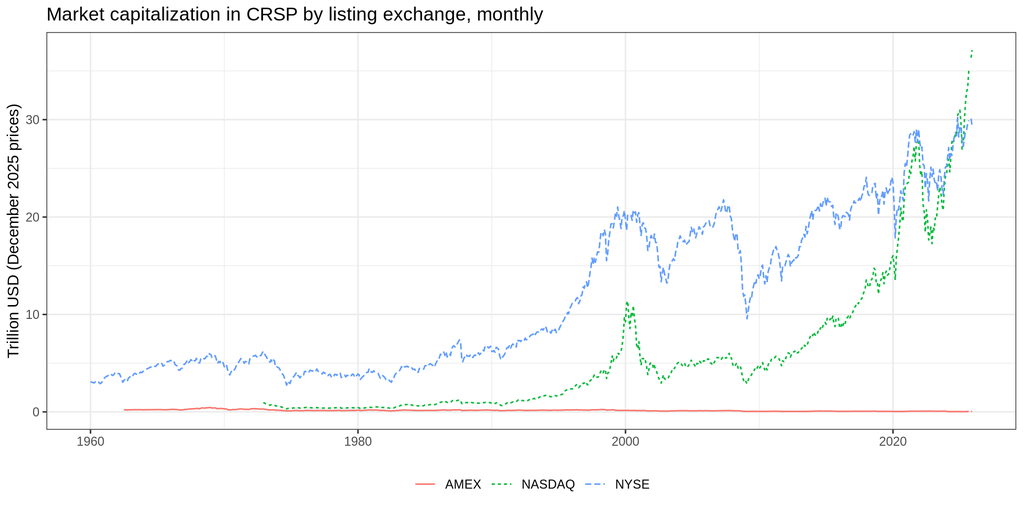

# Tidy coding: the essentials

## Tidy data and the pipe

- **Tidy data:** each variable is a column, each observation a row, each value a cell. CRSP is tidy: one row per stock and month
- **One verb per step, chained:** `|>` in R, method chaining in Python. The code reads like the analysis

```r
# R: stocks per exchange in the latest month
crsp_monthly |>
  filter(date == max(date)) |>
  count(exchange)
```

```
# A data frame: 3 × 2
  exchange     n
  <chr>    <int>
1 AMEX       146
2 NASDAQ    2298
3 NYSE      1241
```

```python
# Python: stocks per exchange in the latest month
(
    crsp_monthly.filter(pl.col("date") == pl.col("date").max())
    .group_by("exchange")
    .len()
    .sort("exchange")
)
```

shape: (3, 2)

| exchange str | len u32 |
| --- | --- |
| "AMEX" | 146 |
| "NASDAQ" | 2298 |
| "NYSE" | 1241 |

- Names say what a column holds (`trading_volume_usd`, not `tmp2`); the [quality criteria](https://aef-course.ku.dk/additional-material/assignment-quality-criteria.html) have the rest

## A first case study: daily returns

- R
- Python

```r
prices <- download_data(
  domain = "Stock Prices",
  symbols = symbols,
  start_date = start_date,
  end_date = end_date
)

returns <- prices |>
  arrange(symbol, date) |>
  mutate(ret = adjusted_close / lag(adjusted_close) - 1, .by = symbol) |>
  select(symbol, date, ret) |>
  drop_na(ret)
```

```python
prices = tf.download_data(
    domain="Stock Prices",
    symbols=symbols,
    start_date=start_date,
    end_date=end_date,
)

returns = (
    prices.sort("symbol", "date")
    .with_columns(ret=pl.col("adjusted_close").pct_change().over("symbol"))
    .select("symbol", "date", "ret")
    .drop_nulls("ret")
)
```

## Summaries by group

- R
- Python

```r
returns |>
  summarize(
    mean = mean(ret),
    sd = sd(ret),
    min = min(ret),
    max = max(ret),
    .by = symbol
  )
```

```
# A tibble: 2 × 5
  symbol     mean     sd    min   max
  <chr>     <dbl>  <dbl>  <dbl> <dbl>
1 AAPL   0.00119  0.0243 -0.519 0.153
2 MSFT   0.000578 0.0189 -0.156 0.196
```

```python
returns.group_by("symbol").agg(
    mean=pl.col("ret").mean(),
    sd=pl.col("ret").std(),
    min=pl.col("ret").min(),
    max=pl.col("ret").max(),
).sort("symbol")
```

shape: (2, 5)

| symbol str | mean f64 | sd f64 | min f64 | max f64 |
| --- | --- | --- | --- | --- |
| "AAPL" | 0.001191 | 0.024263 | -0.518692 | 0.153289 |
| "MSFT" | 0.000578 | 0.018901 | -0.155978 | 0.195652 |

`group_by` and `summarize` (or `agg`) answer many questions in empirical finance

## The grammar of graphics

Data, a geometric shape, and aesthetics that map variables to it: `ggplot2` in R, `plotnine` in Python

- R
- Python

```r
prices |>
  ggplot(aes(x = date, y = adjusted_close)) +
  geom_line() +
  facet_wrap(~symbol, scales = "free_y") +
  labs(x = NULL, y = "USD", title = "Adjusted closing prices of Apple and Microsoft, daily") +
  theme_bw()
```

```python
(
    ggplot(prices, aes(x="date", y="adjusted_close"))
    + geom_line()
    + facet_wrap("symbol", scales="free_y")
    + labs(x="", y="USD", title="Adjusted closing prices of Apple and Microsoft, daily")
    + theme_bw()
)
```

## The grammar of graphics

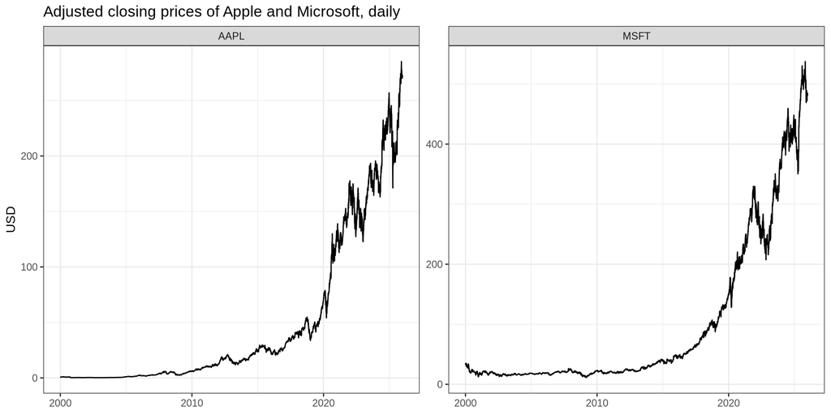

# Wrapping up

## Before the next lecture

1. **Setup:** Positron, uv and uvr, `uvr sync` and `uv sync`, TinyTeX: the [technical prerequisites](https://aef-course.ku.dk/exercises/technical-prerequisites.html)
2. **Data:** put `crsp_monthly.parquet` from Absalon into the `data` folder of the course repository
3. **Exercises:** [Introduction to Tidy Finance](https://aef-course.ku.dk/exercises/introduction.html): reproduce the number of stocks by exchange, then the open question: one figure of your own
4. **Team:** form your team of up to three; send your GitHub usernames through the form on Absalon
5. **Trading game:** try the tools in the dry run (open until 12 February). **TBD:** how teams get their token

## Where to get help

- **Absalon discussion board:** questions about content and code, so everyone benefits from the answer
- **Exercise classes:** open office hours, Mondays 8–10 in odd weeks
- **Your AI assistant:** with the course rules from `AGENTS.md`; you check what it writes
- **The homepage:** aef-course.ku.dk has the lecture plan, the exercises, the trading game and the guides